# Risk Factor Analysis

## Outcome Variable

**Outcome Variable:** haz

## Predictor Variables

**Intervention Variable:** predexfd6

**Adjustment Set:**

- arm
- sex
- W_mage
- meducyrs
- feducyrs
- hhwealth_quart
- hfoodsec
- W_mhtcm
- vagbrth
- W_gagebrth
- W_birthwt
- W_birthlen
- W_nrooms
- W_nchldlt5
- month
- brthmon
- W_parity
- impfloor
- impsan
- safeh20
- delta_W_mage
- delta_meducyrs
- delta_feducyrs
- delta_hhwealth_quart
- delta_hfoodsec
- delta_W_mhtcm
- delta_vagbrth
- delta_W_gagebrth
- delta_W_birthwt
- delta_W_birthlen
- delta_W_nrooms
- delta_W_nchldlt5
- delta_month
- delta_brthmon
- delta_W_parity
- delta_impfloor
- delta_impsan
- delta_safeh20

## Stratifying Variables

The analysis was stratified on these variable(s):

- agecat
- studyid
- country

## Data Summary

| agecat | studyid | country | predexfd6 | n_cell | n |
| --- | --- | --- | --- | --- | --- |
| Birth | ki0047075b-MAL-ED | BANGLADESH | 1 | 119 | 231 |
| Birth | ki0047075b-MAL-ED | BANGLADESH | 0 | 112 | 231 |
| Birth | ki0047075b-MAL-ED | BRAZIL | 1 | 27 | 175 |
| Birth | ki0047075b-MAL-ED | BRAZIL | 0 | 148 | 175 |
| Birth | ki0047075b-MAL-ED | INDIA | 1 | 15 | 190 |
| Birth | ki0047075b-MAL-ED | INDIA | 0 | 175 | 190 |
| Birth | ki0047075b-MAL-ED | NEPAL | 1 | 23 | 170 |
| Birth | ki0047075b-MAL-ED | NEPAL | 0 | 147 | 170 |
| Birth | ki0047075b-MAL-ED | PERU | 1 | 106 | 256 |
| Birth | ki0047075b-MAL-ED | PERU | 0 | 150 | 256 |
| Birth | ki0047075b-MAL-ED | SOUTH AFRICA | 1 | 3 | 211 |
| Birth | ki0047075b-MAL-ED | SOUTH AFRICA | 0 | 208 | 211 |
| Birth | ki0047075b-MAL-ED | TANZANIA, UNITED REPUBLIC OF | 1 | 1 | 119 |
| Birth | ki0047075b-MAL-ED | TANZANIA, UNITED REPUBLIC OF | 0 | 118 | 119 |
| Birth | ki1000108-CMC-V-BCS-2002 | INDIA | 1 | 7 | 7 |
| Birth | ki1000108-CMC-V-BCS-2002 | INDIA | 0 | 0 | 7 |
| Birth | ki1000108-IRC | INDIA | 1 | 0 | 14 |
| Birth | ki1000108-IRC | INDIA | 0 | 14 | 14 |
| Birth | ki1000109-EE | PAKISTAN | 1 | 1 | 2 |
| Birth | ki1000109-EE | PAKISTAN | 0 | 1 | 2 |
| Birth | ki1000304b-SAS-CompFeed | INDIA | 1 | 48 | 50 |
| Birth | ki1000304b-SAS-CompFeed | INDIA | 0 | 2 | 50 |
| Birth | ki1101329-Keneba | GAMBIA | 1 | 484 | 1401 |
| Birth | ki1101329-Keneba | GAMBIA | 0 | 917 | 1401 |
| Birth | kiGH5241-JiVitA-3 | BANGLADESH | 1 | 15096 | 19082 |
| Birth | kiGH5241-JiVitA-3 | BANGLADESH | 0 | 3986 | 19082 |
| Birth | kiGH5241-JiVitA-4 | BANGLADESH | 1 | 619 | 767 |
| Birth | kiGH5241-JiVitA-4 | BANGLADESH | 0 | 148 | 767 |
| 6 months | ki0047075b-MAL-ED | BANGLADESH | 1 | 123 | 235 |
| 6 months | ki0047075b-MAL-ED | BANGLADESH | 0 | 112 | 235 |

[output cut: 64 more lines]

The following strata were considered:

- agecat: 24 months, studyid: ki0047075b-MAL-ED, country: BANGLADESH
- agecat: 24 months, studyid: ki0047075b-MAL-ED, country: BRAZIL
- agecat: 24 months, studyid: ki0047075b-MAL-ED, country: INDIA
- agecat: 24 months, studyid: ki0047075b-MAL-ED, country: NEPAL
- agecat: 24 months, studyid: ki0047075b-MAL-ED, country: PERU
- agecat: 24 months, studyid: ki0047075b-MAL-ED, country: SOUTH AFRICA
- agecat: 24 months, studyid: ki0047075b-MAL-ED, country: TANZANIA, UNITED REPUBLIC OF
- agecat: 24 months, studyid: ki1000108-CMC-V-BCS-2002, country: INDIA
- agecat: 24 months, studyid: ki1000108-IRC, country: INDIA
- agecat: 24 months, studyid: ki1017093b-PROVIDE, country: BANGLADESH
- agecat: 24 months, studyid: ki1101329-Keneba, country: GAMBIA
- agecat: 24 months, studyid: ki1113344-GMS-Nepal, country: NEPAL
- agecat: 24 months, studyid: ki1148112-LCNI-5, country: MALAWI
- agecat: 24 months, studyid: kiGH5241-JiVitA-3, country: BANGLADESH
- agecat: 24 months, studyid: kiGH5241-JiVitA-4, country: BANGLADESH
- agecat: 6 months, studyid: ki0047075b-MAL-ED, country: BANGLADESH
- agecat: 6 months, studyid: ki0047075b-MAL-ED, country: BRAZIL
- agecat: 6 months, studyid: ki0047075b-MAL-ED, country: INDIA
- agecat: 6 months, studyid: ki0047075b-MAL-ED, country: NEPAL
- agecat: 6 months, studyid: ki0047075b-MAL-ED, country: PERU
- agecat: 6 months, studyid: ki0047075b-MAL-ED, country: SOUTH AFRICA
- agecat: 6 months, studyid: ki0047075b-MAL-ED, country: TANZANIA, UNITED REPUBLIC OF
- agecat: 6 months, studyid: ki1000108-CMC-V-BCS-2002, country: INDIA
- agecat: 6 months, studyid: ki1000108-IRC, country: INDIA
- agecat: 6 months, studyid: ki1000109-EE, country: PAKISTAN
- agecat: 6 months, studyid: ki1000304b-SAS-CompFeed, country: INDIA
- agecat: 6 months, studyid: ki1000304b-SAS-FoodSuppl, country: INDIA
- agecat: 6 months, studyid: ki1017093b-PROVIDE, country: BANGLADESH
- agecat: 6 months, studyid: ki1101329-Keneba, country: GAMBIA
- agecat: 6 months, studyid: ki1113344-GMS-Nepal, country: NEPAL
- agecat: 6 months, studyid: ki1148112-LCNI-5, country: MALAWI
- agecat: 6 months, studyid: kiGH5241-JiVitA-3, country: BANGLADESH
- agecat: 6 months, studyid: kiGH5241-JiVitA-4, country: BANGLADESH
- agecat: Birth, studyid: ki0047075b-MAL-ED, country: BANGLADESH
- agecat: Birth, studyid: ki0047075b-MAL-ED, country: BRAZIL
- agecat: Birth, studyid: ki0047075b-MAL-ED, country: INDIA
- agecat: Birth, studyid: ki0047075b-MAL-ED, country: NEPAL
- agecat: Birth, studyid: ki0047075b-MAL-ED, country: PERU
- agecat: Birth, studyid: ki0047075b-MAL-ED, country: SOUTH AFRICA
- agecat: Birth, studyid: ki0047075b-MAL-ED, country: TANZANIA, UNITED REPUBLIC OF
- agecat: Birth, studyid: ki1000108-CMC-V-BCS-2002, country: INDIA
- agecat: Birth, studyid: ki1000108-IRC, country: INDIA
- agecat: Birth, studyid: ki1000109-EE, country: PAKISTAN
- agecat: Birth, studyid: ki1000304b-SAS-CompFeed, country: INDIA
- agecat: Birth, studyid: ki1101329-Keneba, country: GAMBIA
- agecat: Birth, studyid: kiGH5241-JiVitA-3, country: BANGLADESH
- agecat: Birth, studyid: kiGH5241-JiVitA-4, country: BANGLADESH

### Dropped Strata

Some strata were dropped due to rare outcomes:

- agecat: Birth, studyid: ki0047075b-MAL-ED, country: SOUTH AFRICA
- agecat: Birth, studyid: ki0047075b-MAL-ED, country: TANZANIA, UNITED REPUBLIC OF
- agecat: Birth, studyid: ki1000108-CMC-V-BCS-2002, country: INDIA
- agecat: Birth, studyid: ki1000108-IRC, country: INDIA
- agecat: Birth, studyid: ki1000109-EE, country: PAKISTAN
- agecat: Birth, studyid: ki1000304b-SAS-CompFeed, country: INDIA
- agecat: 6 months, studyid: ki0047075b-MAL-ED, country: SOUTH AFRICA
- agecat: 6 months, studyid: ki0047075b-MAL-ED, country: TANZANIA, UNITED REPUBLIC OF
- agecat: 6 months, studyid: ki1000108-CMC-V-BCS-2002, country: INDIA
- agecat: 6 months, studyid: ki1000108-IRC, country: INDIA
- agecat: 6 months, studyid: ki1000304b-SAS-FoodSuppl, country: INDIA
- agecat: 24 months, studyid: ki0047075b-MAL-ED, country: SOUTH AFRICA
- agecat: 24 months, studyid: ki0047075b-MAL-ED, country: TANZANIA, UNITED REPUBLIC OF
- agecat: 24 months, studyid: ki1000108-CMC-V-BCS-2002, country: INDIA
- agecat: 24 months, studyid: ki1000108-IRC, country: INDIA

## Methods Detail

We’re interested in the causal parameters $E[Y_a]$ for all values of $a \in \mathcal{A}$. These parameters represent the mean outcome if, possibly contrary to fact, we intervened to set all units to have $A=a$. Under the randomization and positivity assumptions, these are identified by the statistical parameters $\psi_a=E_W[E_{Y|A,W}(Y|A=a,W)]$. In addition, we’re interested in the mean of $Y$, $E[Y]$ under no intervention (the observed mean). We will estimate these parameters by using SuperLearner to fit the relevant likelihood factors – $E_{Y|A,W}(Y|A=a,W)$ and $p(A=a|W)$, and then updating our likelihood fit using a joint TMLE.

For unadjusted analyses ($W=\{\}$), initial likelihoods were estimated using Lrnr_glm to estimate the simple $E(Y|A)$ and Lrnr_mean to estimate $p(A)$. For adjusted analyses, a small library containing Lrnr_glmnet, Lrnr_xgboost, and Lrnr_mean was used.

Having estimated these parameters, we will then use the delta method to estimate relative risks and attributable risks relative to a prespecified baseline level of $A$.

# Results Detail

## Results Plots

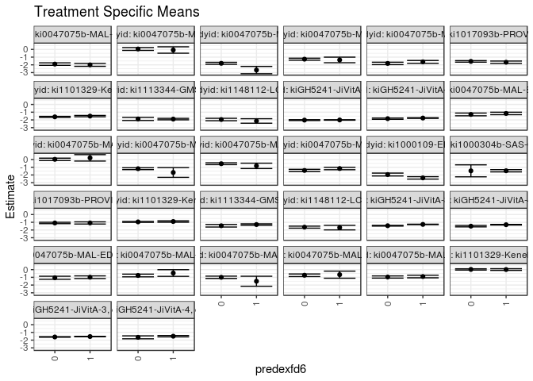

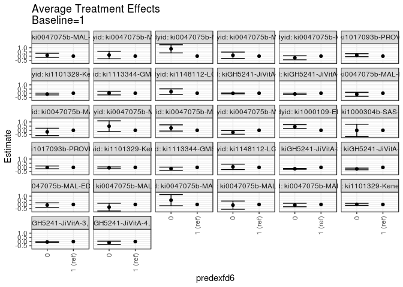

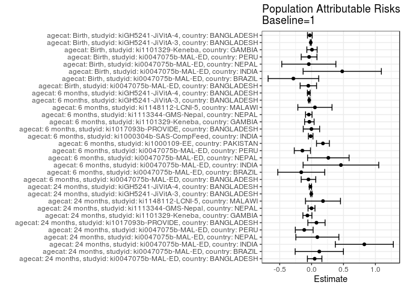

## Results Table

### Parameter: TSM

| agecat | studyid | country | intervention_level | baseline_level | estimate | ci_lower | ci_upper |
| --- | --- | --- | --- | --- | --- | --- | --- |
| Birth | ki0047075b-MAL-ED | BANGLADESH | 1 | NA | -0.9806682 | -1.1528348 | -0.8085016 |
| Birth | ki0047075b-MAL-ED | BANGLADESH | 0 | NA | -1.0535316 | -1.2504161 | -0.8566471 |
| Birth | ki0047075b-MAL-ED | BRAZIL | 1 | NA | -0.4409592 | -0.8724842 | -0.0094342 |
| Birth | ki0047075b-MAL-ED | BRAZIL | 0 | NA | -0.7574648 | -0.9322306 | -0.5826989 |
| Birth | ki0047075b-MAL-ED | INDIA | 1 | NA | -1.5052108 | -2.1533105 | -0.8571111 |
| Birth | ki0047075b-MAL-ED | INDIA | 0 | NA | -0.9924934 | -1.1416844 | -0.8433024 |
| Birth | ki0047075b-MAL-ED | NEPAL | 1 | NA | -0.6528467 | -1.1115245 | -0.1941688 |
| Birth | ki0047075b-MAL-ED | NEPAL | 0 | NA | -0.7305332 | -0.8986970 | -0.5623694 |
| Birth | ki0047075b-MAL-ED | PERU | 1 | NA | -0.8917505 | -1.0610748 | -0.7224263 |
| Birth | ki0047075b-MAL-ED | PERU | 0 | NA | -0.9558314 | -1.0960981 | -0.8155648 |
| Birth | ki1101329-Keneba | GAMBIA | 1 | NA | 0.0102388 | -0.0970320 | 0.1175095 |
| Birth | ki1101329-Keneba | GAMBIA | 0 | NA | 0.0264279 | -0.0523896 | 0.1052455 |
| Birth | kiGH5241-JiVitA-3 | BANGLADESH | 1 | NA | -1.5366181 | -1.5570812 | -1.5161550 |
| Birth | kiGH5241-JiVitA-3 | BANGLADESH | 0 | NA | -1.5919490 | -1.6252531 | -1.5586448 |
| Birth | kiGH5241-JiVitA-4 | BANGLADESH | 1 | NA | -1.4933208 | -1.5819002 | -1.4047414 |
| Birth | kiGH5241-JiVitA-4 | BANGLADESH | 0 | NA | -1.6378157 | -1.8270639 | -1.4485675 |
| 6 months | ki0047075b-MAL-ED | BANGLADESH | 1 | NA | -1.1646831 | -1.3244691 | -1.0048972 |
| 6 months | ki0047075b-MAL-ED | BANGLADESH | 0 | NA | -1.2918853 | -1.4687025 | -1.1150681 |
| 6 months | ki0047075b-MAL-ED | BRAZIL | 1 | NA | 0.2136575 | -0.2002381 | 0.6275531 |
| 6 months | ki0047075b-MAL-ED | BRAZIL | 0 | NA | 0.0227705 | -0.1292834 | 0.1748245 |
| 6 months | ki0047075b-MAL-ED | INDIA | 1 | NA | -1.6789940 | -2.3077978 | -1.0501903 |
| 6 months | ki0047075b-MAL-ED | INDIA | 0 | NA | -1.1901304 | -1.3089176 | -1.0713432 |
| 6 months | ki0047075b-MAL-ED | NEPAL | 1 | NA | -0.8218825 | -1.1698056 | -0.4739593 |
| 6 months | ki0047075b-MAL-ED | NEPAL | 0 | NA | -0.5429932 | -0.6629972 | -0.4229892 |
| 6 months | ki0047075b-MAL-ED | PERU | 1 | NA | -1.1648668 | -1.3236265 | -1.0061071 |
| 6 months | ki0047075b-MAL-ED | PERU | 0 | NA | -1.4148721 | -1.5586545 | -1.2710898 |
| 6 months | ki1000109-EE | PAKISTAN | 1 | NA | -2.3783175 | -2.5349720 | -2.2216631 |
| 6 months | ki1000109-EE | PAKISTAN | 0 | NA | -1.9453314 | -2.1317206 | -1.7589422 |
| 6 months | ki1000304b-SAS-CompFeed | INDIA | 1 | NA | -1.4549959 | -1.6008850 | -1.3091069 |
| 6 months | ki1000304b-SAS-CompFeed | INDIA | 0 | NA | -1.4654856 | -2.2428805 | -0.6880907 |
| 6 months | ki1017093b-PROVIDE | BANGLADESH | 1 | NA | -1.0845061 | -1.2251910 | -0.9438211 |
| 6 months | ki1017093b-PROVIDE | BANGLADESH | 0 | NA | -1.0869834 | -1.1771990 | -0.9967679 |
| 6 months | ki1101329-Keneba | GAMBIA | 1 | NA | -0.8978988 | -0.9875559 | -0.8082417 |
| 6 months | ki1101329-Keneba | GAMBIA | 0 | NA | -0.9474735 | -1.0065561 | -0.8883909 |
| 6 months | ki1113344-GMS-Nepal | NEPAL | 1 | NA | -1.2910668 | -1.3810776 | -1.2010561 |
| 6 months | ki1113344-GMS-Nepal | NEPAL | 0 | NA | -1.4466099 | -1.6125504 | -1.2806694 |
| 6 months | ki1148112-LCNI-5 | MALAWI | 1 | NA | -1.6917856 | -1.9866035 | -1.3969678 |
| 6 months | ki1148112-LCNI-5 | MALAWI | 0 | NA | -1.6271150 | -1.7578828 | -1.4963472 |
| 6 months | kiGH5241-JiVitA-3 | BANGLADESH | 1 | NA | -1.2732283 | -1.2982075 | -1.2482492 |
| 6 months | kiGH5241-JiVitA-3 | BANGLADESH | 0 | NA | -1.4434311 | -1.4885886 | -1.3982737 |
| 6 months | kiGH5241-JiVitA-4 | BANGLADESH | 1 | NA | -1.3134898 | -1.3553886 | -1.2715910 |
| 6 months | kiGH5241-JiVitA-4 | BANGLADESH | 0 | NA | -1.5011974 | -1.5935292 | -1.4088655 |
| 24 months | ki0047075b-MAL-ED | BANGLADESH | 1 | NA | -2.0012346 | -2.1880867 | -1.8143825 |
| 24 months | ki0047075b-MAL-ED | BANGLADESH | 0 | NA | -1.9019482 | -2.0630294 | -1.7408671 |
| 24 months | ki0047075b-MAL-ED | BRAZIL | 1 | NA | -0.0788948 | -0.4927741 | 0.3349844 |
| 24 months | ki0047075b-MAL-ED | BRAZIL | 0 | NA | 0.0535639 | -0.1313791 | 0.2385070 |
| 24 months | ki0047075b-MAL-ED | INDIA | 1 | NA | -2.6730182 | -3.1440048 | -2.2020316 |
| 24 months | ki0047075b-MAL-ED | INDIA | 0 | NA | -1.8016143 | -1.9309578 | -1.6722708 |
| 24 months | ki0047075b-MAL-ED | NEPAL | 1 | NA | -1.3644186 | -1.7251778 | -1.0036594 |
| 24 months | ki0047075b-MAL-ED | NEPAL | 0 | NA | -1.2651308 | -1.3940090 | -1.1362525 |
| 24 months | ki0047075b-MAL-ED | PERU | 1 | NA | -1.6137962 | -1.7927932 | -1.4347991 |
| 24 months | ki0047075b-MAL-ED | PERU | 0 | NA | -1.8136820 | -1.9716714 | -1.6556927 |
| 24 months | ki1017093b-PROVIDE | BANGLADESH | 1 | NA | -1.6621994 | -1.8158845 | -1.5085144 |
| 24 months | ki1017093b-PROVIDE | BANGLADESH | 0 | NA | -1.5524585 | -1.6487606 | -1.4561563 |
| 24 months | ki1101329-Keneba | GAMBIA | 1 | NA | -1.5063201 | -1.5915520 | -1.4210881 |
| 24 months | ki1101329-Keneba | GAMBIA | 0 | NA | -1.6043308 | -1.6708217 | -1.5378399 |
| 24 months | ki1113344-GMS-Nepal | NEPAL | 1 | NA | -1.8936182 | -1.9876635 | -1.7995730 |
| 24 months | ki1113344-GMS-Nepal | NEPAL | 0 | NA | -1.8745164 | -2.0740469 | -1.6749859 |
| 24 months | ki1148112-LCNI-5 | MALAWI | 1 | NA | -2.1390470 | -2.4298772 | -1.8482168 |
| 24 months | ki1148112-LCNI-5 | MALAWI | 0 | NA | -1.9503659 | -2.1077009 | -1.7930308 |
| 24 months | kiGH5241-JiVitA-3 | BANGLADESH | 1 | NA | -2.0072656 | -2.0363781 | -1.9781531 |
| 24 months | kiGH5241-JiVitA-3 | BANGLADESH | 0 | NA | -2.0247384 | -2.0758642 | -1.9736125 |
| 24 months | kiGH5241-JiVitA-4 | BANGLADESH | 1 | NA | -1.7575661 | -1.7993652 | -1.7157671 |
| 24 months | kiGH5241-JiVitA-4 | BANGLADESH | 0 | NA | -1.8383635 | -1.9189296 | -1.7577973 |

### Parameter: E(Y)

| agecat | studyid | country | intervention_level | baseline_level | estimate | ci_lower | ci_upper |
| --- | --- | --- | --- | --- | --- | --- | --- |
| Birth | ki0047075b-MAL-ED | BANGLADESH | NA | NA | -1.0317316 | -1.1618799 | -0.9015833 |
| Birth | ki0047075b-MAL-ED | BRAZIL | NA | NA | -0.7263429 | -0.8876385 | -0.5650472 |
| Birth | ki0047075b-MAL-ED | INDIA | NA | NA | -1.0250526 | -1.1724135 | -0.8776918 |
| Birth | ki0047075b-MAL-ED | NEPAL | NA | NA | -0.6964706 | -0.8552823 | -0.5376589 |
| Birth | ki0047075b-MAL-ED | PERU | NA | NA | -0.9311719 | -1.0458986 | -0.8164451 |
| Birth | ki1101329-Keneba | GAMBIA | NA | NA | 0.0162027 | -0.0517648 | 0.0841702 |
| Birth | kiGH5241-JiVitA-3 | BANGLADESH | NA | NA | -1.5502914 | -1.5696478 | -1.5309349 |
| Birth | kiGH5241-JiVitA-4 | BANGLADESH | NA | NA | -1.5207432 | -1.6058630 | -1.4356233 |
| 6 months | ki0047075b-MAL-ED | BANGLADESH | NA | NA | -1.2140355 | -1.3320337 | -1.0960372 |
| 6 months | ki0047075b-MAL-ED | BRAZIL | NA | NA | 0.0510207 | -0.0930194 | 0.1950608 |
| 6 months | ki0047075b-MAL-ED | INDIA | NA | NA | -1.2193606 | -1.3390323 | -1.0996890 |
| 6 months | ki0047075b-MAL-ED | NEPAL | NA | NA | -0.5595745 | -0.6727496 | -0.4463993 |
| 6 months | ki0047075b-MAL-ED | PERU | NA | NA | -1.3092999 | -1.4165606 | -1.2020392 |
| 6 months | ki1000109-EE | PAKISTAN | NA | NA | -2.2004704 | -2.3234073 | -2.0775336 |
| 6 months | ki1000304b-SAS-CompFeed | INDIA | NA | NA | -1.4697236 | -1.6333919 | -1.3060553 |
| 6 months | ki1017093b-PROVIDE | BANGLADESH | NA | NA | -1.0871041 | -1.1635539 | -1.0106543 |
| 6 months | ki1101329-Keneba | GAMBIA | NA | NA | -0.9331108 | -0.9823173 | -0.8839043 |
| 6 months | ki1113344-GMS-Nepal | NEPAL | NA | NA | -1.3352045 | -1.4146382 | -1.2557708 |
| 6 months | ki1148112-LCNI-5 | MALAWI | NA | NA | -1.6395956 | -1.7592633 | -1.5199278 |
| 6 months | kiGH5241-JiVitA-3 | BANGLADESH | NA | NA | -1.3104400 | -1.3338132 | -1.2870668 |
| 6 months | kiGH5241-JiVitA-4 | BANGLADESH | NA | NA | -1.3574771 | -1.3964060 | -1.3185482 |
| 24 months | ki0047075b-MAL-ED | BANGLADESH | NA | NA | -1.9532775 | -2.0781247 | -1.8284303 |
| 24 months | ki0047075b-MAL-ED | BRAZIL | NA | NA | 0.0418343 | -0.1253834 | 0.2090521 |
| 24 months | ki0047075b-MAL-ED | INDIA | NA | NA | -1.8466071 | -1.9736347 | -1.7195796 |
| 24 months | ki0047075b-MAL-ED | NEPAL | NA | NA | -1.2744493 | -1.3952297 | -1.1536689 |
| 24 months | ki0047075b-MAL-ED | PERU | NA | NA | -1.7294949 | -1.8488722 | -1.6101177 |
| 24 months | ki1017093b-PROVIDE | BANGLADESH | NA | NA | -1.5861179 | -1.6693668 | -1.5028689 |
| 24 months | ki1101329-Keneba | GAMBIA | NA | NA | -1.5721046 | -1.6251725 | -1.5190368 |
| 24 months | ki1113344-GMS-Nepal | NEPAL | NA | NA | -1.8951389 | -1.9810871 | -1.8091907 |
| 24 months | ki1148112-LCNI-5 | MALAWI | NA | NA | -1.9605820 | -2.1001715 | -1.8209925 |
| 24 months | kiGH5241-JiVitA-3 | BANGLADESH | NA | NA | -2.0122091 | -2.0399540 | -1.9844641 |
| 24 months | kiGH5241-JiVitA-4 | BANGLADESH | NA | NA | -1.7762003 | -1.8148628 | -1.7375378 |

### Parameter: ATE

| agecat | studyid | country | intervention_level | baseline_level | estimate | ci_lower | ci_upper |
| --- | --- | --- | --- | --- | --- | --- | --- |
| Birth | ki0047075b-MAL-ED | BANGLADESH | 1 | 1 | 0.0000000 | 0.0000000 | 0.0000000 |
| Birth | ki0047075b-MAL-ED | BANGLADESH | 0 | 1 | -0.0728634 | -0.3355598 | 0.1898330 |
| Birth | ki0047075b-MAL-ED | BRAZIL | 1 | 1 | 0.0000000 | 0.0000000 | 0.0000000 |
| Birth | ki0047075b-MAL-ED | BRAZIL | 0 | 1 | -0.3165055 | -0.7813153 | 0.1483042 |
| Birth | ki0047075b-MAL-ED | INDIA | 1 | 1 | 0.0000000 | 0.0000000 | 0.0000000 |
| Birth | ki0047075b-MAL-ED | INDIA | 0 | 1 | 0.5127174 | -0.1522791 | 1.1777140 |
| Birth | ki0047075b-MAL-ED | NEPAL | 1 | 1 | 0.0000000 | 0.0000000 | 0.0000000 |
| Birth | ki0047075b-MAL-ED | NEPAL | 0 | 1 | -0.0776866 | -0.5669380 | 0.4115649 |
| Birth | ki0047075b-MAL-ED | PERU | 1 | 1 | 0.0000000 | 0.0000000 | 0.0000000 |
| Birth | ki0047075b-MAL-ED | PERU | 0 | 1 | -0.0640809 | -0.2735880 | 0.1454262 |
| Birth | ki1101329-Keneba | GAMBIA | 1 | 1 | 0.0000000 | 0.0000000 | 0.0000000 |
| Birth | ki1101329-Keneba | GAMBIA | 0 | 1 | 0.0161892 | -0.1065378 | 0.1389161 |
| Birth | kiGH5241-JiVitA-3 | BANGLADESH | 1 | 1 | 0.0000000 | 0.0000000 | 0.0000000 |
| Birth | kiGH5241-JiVitA-3 | BANGLADESH | 0 | 1 | -0.0553309 | -0.0887316 | -0.0219301 |
| Birth | kiGH5241-JiVitA-4 | BANGLADESH | 1 | 1 | 0.0000000 | 0.0000000 | 0.0000000 |
| Birth | kiGH5241-JiVitA-4 | BANGLADESH | 0 | 1 | -0.1444949 | -0.3403102 | 0.0513205 |
| 6 months | ki0047075b-MAL-ED | BANGLADESH | 1 | 1 | 0.0000000 | 0.0000000 | 0.0000000 |
| 6 months | ki0047075b-MAL-ED | BANGLADESH | 0 | 1 | -0.1272021 | -0.3661957 | 0.1117914 |
| 6 months | ki0047075b-MAL-ED | BRAZIL | 1 | 1 | 0.0000000 | 0.0000000 | 0.0000000 |
| 6 months | ki0047075b-MAL-ED | BRAZIL | 0 | 1 | -0.1908870 | -0.6302716 | 0.2484976 |
| 6 months | ki0047075b-MAL-ED | INDIA | 1 | 1 | 0.0000000 | 0.0000000 | 0.0000000 |
| 6 months | ki0047075b-MAL-ED | INDIA | 0 | 1 | 0.4888636 | -0.1511467 | 1.1288740 |
| 6 months | ki0047075b-MAL-ED | NEPAL | 1 | 1 | 0.0000000 | 0.0000000 | 0.0000000 |
| 6 months | ki0047075b-MAL-ED | NEPAL | 0 | 1 | 0.2788893 | -0.0899531 | 0.6477316 |
| 6 months | ki0047075b-MAL-ED | PERU | 1 | 1 | 0.0000000 | 0.0000000 | 0.0000000 |
| 6 months | ki0047075b-MAL-ED | PERU | 0 | 1 | -0.2500053 | -0.4646431 | -0.0353675 |
| 6 months | ki1000109-EE | PAKISTAN | 1 | 1 | 0.0000000 | 0.0000000 | 0.0000000 |
| 6 months | ki1000109-EE | PAKISTAN | 0 | 1 | 0.4329861 | 0.1941169 | 0.6718552 |
| 6 months | ki1000304b-SAS-CompFeed | INDIA | 1 | 1 | 0.0000000 | 0.0000000 | 0.0000000 |
| 6 months | ki1000304b-SAS-CompFeed | INDIA | 0 | 1 | -0.0104897 | -0.7471588 | 0.7261794 |
| 6 months | ki1017093b-PROVIDE | BANGLADESH | 1 | 1 | 0.0000000 | 0.0000000 | 0.0000000 |
| 6 months | ki1017093b-PROVIDE | BANGLADESH | 0 | 1 | -0.0024774 | -0.1696717 | 0.1647169 |
| 6 months | ki1101329-Keneba | GAMBIA | 1 | 1 | 0.0000000 | 0.0000000 | 0.0000000 |
| 6 months | ki1101329-Keneba | GAMBIA | 0 | 1 | -0.0495748 | -0.1565600 | 0.0574105 |
| 6 months | ki1113344-GMS-Nepal | NEPAL | 1 | 1 | 0.0000000 | 0.0000000 | 0.0000000 |
| 6 months | ki1113344-GMS-Nepal | NEPAL | 0 | 1 | -0.1555431 | -0.3444735 | 0.0333873 |
| 6 months | ki1148112-LCNI-5 | MALAWI | 1 | 1 | 0.0000000 | 0.0000000 | 0.0000000 |
| 6 months | ki1148112-LCNI-5 | MALAWI | 0 | 1 | 0.0646706 | -0.2548601 | 0.3842013 |
| 6 months | kiGH5241-JiVitA-3 | BANGLADESH | 1 | 1 | 0.0000000 | 0.0000000 | 0.0000000 |
| 6 months | kiGH5241-JiVitA-3 | BANGLADESH | 0 | 1 | -0.1702028 | -0.2173597 | -0.1230459 |
| 6 months | kiGH5241-JiVitA-4 | BANGLADESH | 1 | 1 | 0.0000000 | 0.0000000 | 0.0000000 |
| 6 months | kiGH5241-JiVitA-4 | BANGLADESH | 0 | 1 | -0.1877075 | -0.2878341 | -0.0875810 |
| 24 months | ki0047075b-MAL-ED | BANGLADESH | 1 | 1 | 0.0000000 | 0.0000000 | 0.0000000 |
| 24 months | ki0047075b-MAL-ED | BANGLADESH | 0 | 1 | 0.0992864 | -0.1481475 | 0.3467203 |
| 24 months | ki0047075b-MAL-ED | BRAZIL | 1 | 1 | 0.0000000 | 0.0000000 | 0.0000000 |
| 24 months | ki0047075b-MAL-ED | BRAZIL | 0 | 1 | 0.1324588 | -0.3199865 | 0.5849041 |
| 24 months | ki0047075b-MAL-ED | INDIA | 1 | 1 | 0.0000000 | 0.0000000 | 0.0000000 |
| 24 months | ki0047075b-MAL-ED | INDIA | 0 | 1 | 0.8714039 | 0.3830500 | 1.3597578 |
| 24 months | ki0047075b-MAL-ED | NEPAL | 1 | 1 | 0.0000000 | 0.0000000 | 0.0000000 |
| 24 months | ki0047075b-MAL-ED | NEPAL | 0 | 1 | 0.0992878 | -0.2841297 | 0.4827054 |
| 24 months | ki0047075b-MAL-ED | PERU | 1 | 1 | 0.0000000 | 0.0000000 | 0.0000000 |
| 24 months | ki0047075b-MAL-ED | PERU | 0 | 1 | -0.1998859 | -0.4384754 | 0.0387037 |
| 24 months | ki1017093b-PROVIDE | BANGLADESH | 1 | 1 | 0.0000000 | 0.0000000 | 0.0000000 |
| 24 months | ki1017093b-PROVIDE | BANGLADESH | 0 | 1 | 0.1097410 | -0.0689714 | 0.2884534 |
| 24 months | ki1101329-Keneba | GAMBIA | 1 | 1 | 0.0000000 | 0.0000000 | 0.0000000 |
| 24 months | ki1101329-Keneba | GAMBIA | 0 | 1 | -0.0980108 | -0.2045473 | 0.0085258 |
| 24 months | ki1113344-GMS-Nepal | NEPAL | 1 | 1 | 0.0000000 | 0.0000000 | 0.0000000 |
| 24 months | ki1113344-GMS-Nepal | NEPAL | 0 | 1 | 0.0191018 | -0.2014259 | 0.2396295 |
| 24 months | ki1148112-LCNI-5 | MALAWI | 1 | 1 | 0.0000000 | 0.0000000 | 0.0000000 |
| 24 months | ki1148112-LCNI-5 | MALAWI | 0 | 1 | 0.1886811 | -0.1430508 | 0.5204130 |
| 24 months | kiGH5241-JiVitA-3 | BANGLADESH | 1 | 1 | 0.0000000 | 0.0000000 | 0.0000000 |
| 24 months | kiGH5241-JiVitA-3 | BANGLADESH | 0 | 1 | -0.0174728 | -0.0690737 | 0.0341281 |
| 24 months | kiGH5241-JiVitA-4 | BANGLADESH | 1 | 1 | 0.0000000 | 0.0000000 | 0.0000000 |
| 24 months | kiGH5241-JiVitA-4 | BANGLADESH | 0 | 1 | -0.0807973 | -0.1669298 | 0.0053351 |

### Parameter: PAR

| agecat | studyid | country | intervention_level | baseline_level | estimate | ci_lower | ci_upper |
| --- | --- | --- | --- | --- | --- | --- | --- |
| Birth | ki0047075b-MAL-ED | BANGLADESH | 1 | NA | -0.0510634 | -0.1798510 | 0.0777241 |
| Birth | ki0047075b-MAL-ED | BRAZIL | 1 | NA | -0.2853836 | -0.6819997 | 0.1112324 |
| Birth | ki0047075b-MAL-ED | INDIA | 1 | NA | 0.4801582 | -0.1333816 | 1.0936979 |
| Birth | ki0047075b-MAL-ED | NEPAL | 1 | NA | -0.0436239 | -0.4677816 | 0.3805337 |
| Birth | ki0047075b-MAL-ED | PERU | 1 | NA | -0.0394213 | -0.1628031 | 0.0839604 |
| Birth | ki1101329-Keneba | GAMBIA | 1 | NA | 0.0059640 | -0.0745649 | 0.0864928 |
| Birth | kiGH5241-JiVitA-3 | BANGLADESH | 1 | NA | -0.0136733 | -0.0214357 | -0.0059108 |
| Birth | kiGH5241-JiVitA-4 | BANGLADESH | 1 | NA | -0.0274223 | -0.0641949 | 0.0093502 |
| 6 months | ki0047075b-MAL-ED | BANGLADESH | 1 | NA | -0.0493523 | -0.1633163 | 0.0646117 |
| 6 months | ki0047075b-MAL-ED | BRAZIL | 1 | NA | -0.1626368 | -0.5307661 | 0.2054925 |
| 6 months | ki0047075b-MAL-ED | INDIA | 1 | NA | 0.4596334 | -0.1332745 | 1.0525414 |
| 6 months | ki0047075b-MAL-ED | NEPAL | 1 | NA | 0.2623080 | -0.0629313 | 0.5875473 |
| 6 months | ki0047075b-MAL-ED | PERU | 1 | NA | -0.1444330 | -0.2716085 | -0.0172575 |
| 6 months | ki1000109-EE | PAKISTAN | 1 | NA | 0.1778471 | 0.0771722 | 0.2785219 |
| 6 months | ki1000304b-SAS-CompFeed | INDIA | 1 | NA | -0.0147277 | -0.0507565 | 0.0213012 |
| 6 months | ki1017093b-PROVIDE | BANGLADESH | 1 | NA | -0.0025980 | -0.1309599 | 0.1257639 |
| 6 months | ki1101329-Keneba | GAMBIA | 1 | NA | -0.0352120 | -0.1098296 | 0.0394056 |
| 6 months | ki1113344-GMS-Nepal | NEPAL | 1 | NA | -0.0441377 | -0.0949370 | 0.0066617 |
| 6 months | ki1148112-LCNI-5 | MALAWI | 1 | NA | 0.0521900 | -0.2156931 | 0.3200731 |
| 6 months | kiGH5241-JiVitA-3 | BANGLADESH | 1 | NA | -0.0372117 | -0.0474975 | -0.0269258 |
| 6 months | kiGH5241-JiVitA-4 | BANGLADESH | 1 | NA | -0.0439873 | -0.0656386 | -0.0223360 |
| 24 months | ki0047075b-MAL-ED | BANGLADESH | 1 | NA | 0.0479571 | -0.0655568 | 0.1614710 |
| 24 months | ki0047075b-MAL-ED | BRAZIL | 1 | NA | 0.1207292 | -0.2575907 | 0.4990490 |
| 24 months | ki0047075b-MAL-ED | INDIA | 1 | NA | 0.8264110 | 0.3714331 | 1.2813890 |
| 24 months | ki0047075b-MAL-ED | NEPAL | 1 | NA | 0.0899693 | -0.2473962 | 0.4273347 |
| 24 months | ki0047075b-MAL-ED | PERU | 1 | NA | -0.1156988 | -0.2551652 | 0.0237677 |
| 24 months | ki1017093b-PROVIDE | BANGLADESH | 1 | NA | 0.0760816 | -0.0588752 | 0.2110384 |
| 24 months | ki1101329-Keneba | GAMBIA | 1 | NA | -0.0657846 | -0.1364862 | 0.0049170 |
| 24 months | ki1113344-GMS-Nepal | NEPAL | 1 | NA | -0.0015206 | -0.0557371 | 0.0526958 |
| 24 months | ki1148112-LCNI-5 | MALAWI | 1 | NA | 0.1784650 | -0.0960347 | 0.4529647 |
| 24 months | kiGH5241-JiVitA-3 | BANGLADESH | 1 | NA | -0.0049435 | -0.0162703 | 0.0063833 |
| 24 months | kiGH5241-JiVitA-4 | BANGLADESH | 1 | NA | -0.0186342 | -0.0365152 | -0.0007531 |